## Calotis glandulosa

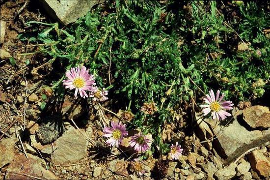

### Predicted suitability of SoS site network under 2070 climate

Climatic suitability is derived from NARCliM projections, using the 2070 timepoint of the habitat suitability model developed for the NSW Adaptation Hub BioNode by Baumgartner et al. (2017); see SoS Site Network Review Report for further detail on methods.

##### Species distribution summary

*Area of Occupancy is calculated at 1km resolution; Locations refer to groups of spatially adjacent AOO gridcells.*

[output not shown]

##### Future climate suitability of SoS sites

*Figures shown below indicate the amount (in deg C or mm of precipitation) by which the site is predicted to be outside the species’ current environmental niche. I.e. a value of 2 deg. C would indicate that the site will be 2 deg. C greater than anywhere that the species is currently known to exist.* N.B *Known observations must be within SoS sites to count towards ‘AOO in SoS sites.’*

| SoS site name | Mean diurnal range (deg C) | Temp. seasonality (deg C) | Max. temp. of warmest month (deg C) | Min. temp. of coldest month (deg C) | Precip. of wettest month (mm) | Precip. of driest month (mm) | Precip. seasonality (CV) | Climate suitable in 2070 | Climate suitable in 2070 (lenient threshold) |
| --- | --- | --- | --- | --- | --- | --- | --- | --- | --- |
| Back Creek Travelling Stock Reserve | 0 | 0.00 | 2.56 | 2.04 | 0 | 0.00 | 0.00 | FALSE | FALSE |
| Bibbenluke Common | 0 | 0.00 | 0.99 | 1.11 | 0 | 0.32 | 3.77 | FALSE | FALSE |
| Kellys Plain | 0 | 0.02 | 0.00 | 0.41 | 0 | 0.00 | 0.00 | FALSE | FALSE |
| Lake Eucumbene area | 0 | 0.03 | 0.00 | 0.00 | 0 | 0.00 | 0.00 | TRUE | TRUE |
| Nungar Plain | 0 | 0.00 | 0.00 | 0.04 | 0 | 0.00 | 0.00 | FALSE | FALSE |

##### Species distribution map

*Mouse-over features for information.*

[interactive chart not shown]

### Niche representativeness of SoS site network

##### Niche occupancy of SoS sites under current and future climates

*Density plot of area occupied by the species across environmental gradients. Predicted 2070 values for SoS sites are indicated by red markers. To maximise adaptive capacity, SoS sites should represent the full range of values for as many of these environmental gradients as possible. Where markers do not overlap with the current (grey) distribution, those sites are likely to be climatically unsuitable in 2070.*

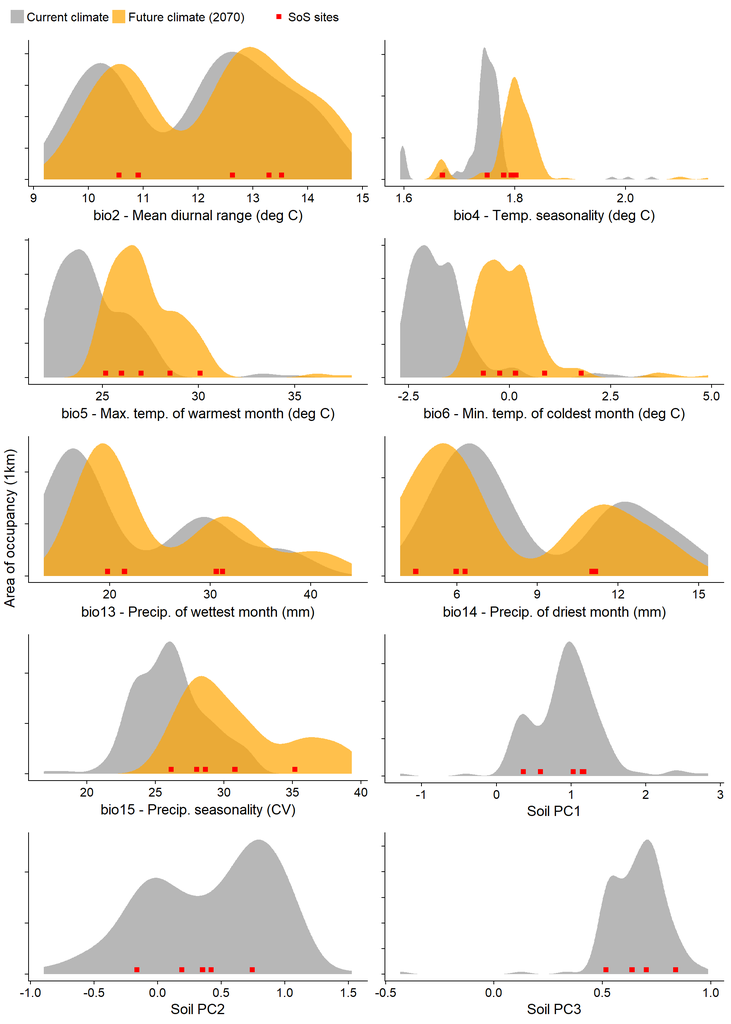

##### Univariate niche occupancy

| Group | Soil PC1 | Soil PC2 | Soil PC3 | Mean diurnal range (deg C) | Temp. seasonality (deg C) | Max. temp. of warmest month (deg C) | Min. temp. of coldest month (deg C) | Precip. of wettest month (mm) | Precip. of driest month (mm) | Precip. seasonality (CV) |
| --- | --- | --- | --- | --- | --- | --- | --- | --- | --- | --- |
| All gridcells | 0.70 | 0.85 | 0.55 | 0.9 | 0.45 | 0.6 | 0.65 | 0.90 | 0.90 | 0.85 |
| SoS site gricells | 0.45 | 0.65 | 0.55 | 0.4 | 0.25 | 0.4 | 0.25 | 0.45 | 0.45 | 0.50 |

*Univariate niche occupancy is calculated for each environmental variable by scaling datapoints to 0 and 1, and then dividing them into 20 equal bins. Occupancy is equal to the fraction of these bins occupied.*

##### Univariate niche breadth

| Group | Soil PC1 | Soil PC2 | Soil PC3 | Mean diurnal range (deg C) | Temp. seasonality (deg C) | Max. temp. of warmest month (deg C) | Min. temp. of coldest month (deg C) | Precip. of wettest month (mm) | Precip. of driest month (mm) | Precip. seasonality (CV) |
| --- | --- | --- | --- | --- | --- | --- | --- | --- | --- | --- |
| All gridcells | 4.1 | 2.4 | 1.4 | 5.6 | 0.5 | 13.1 | 6.1 | 26.6 | 10.7 | 14.9 |
| SoS site gricells | 2.0 | 1.9 | 0.4 | 3.4 | 0.2 | 5.4 | 2.6 | 15.6 | 7.0 | 4.6 |

*Univariate niche breadth is calculated for each environmental variable by subtracting the minimum value from the maximum value.*

##### Distribution of locations in multivariate environmental space

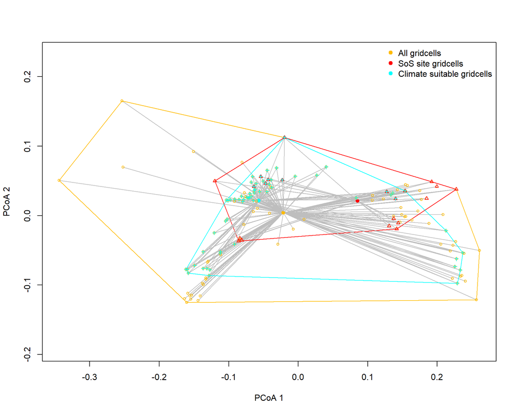

*This ordination plot shows how the species is distributed in environmental space, where all climate and soil variables shown above are reduced to two dimensions. 1km gridcells occupied by the species are shown as points; the closer these points are together in the plot, the more similar their environmental properties. Coloured polygons indicate the boundaries of the niche occupied by each group of points. To minimise exposure to climate change risk, managed locations should cover as much of the space delineated by the ‘Climate suitable gridcells’ polygon as possible, and points should be evenly distributed throughout this space.*

##### Summary of occupancy in present-day multivariate environmental space

| Group | Occupancy | Dispersion |
| --- | --- | --- |
| All gridcells | 0.45 | 0.49 |
| Climate suitable gridcells | 0.35 | 0.30 |
| SoS site gricells | 0.25 | 0.19 |

*These metrics summarise the distribution of distances from the environmental ‘centroid’ (shown as the filled circles in the plot above) to each of the points. This information can help us understand how much environmental space is occupied, and in what pattern. Occupancy measures how much of the total environmental niche actually supports known populations of a species, and is calculated by splitting distances to centroids into 20 equal-sized ‘bins’, counting the number of bins which contain at least one value, and dividing by 20. Dispersion is a measure of the size of the total environmental area occupied by the species, and is calculated by subtracting the smallest distance from the largest distance. Unlike occupancy, dispersion is a relative measure which can not be compared between specices. Both values range between 0 and 1, and higher values of both for managed locations indicate more comprehensive niche representation.*